```python
import matplotlib.pyplot as plt
import os

# Crear el directorio para las imágenes
if not os.path.exists('imgs'):
    os.makedirs('imgs')

plt.style.use('seaborn-v0_8-muted') # Estilo limpio
```

# Gráfico de Líneas (Evolución de Temperatura)

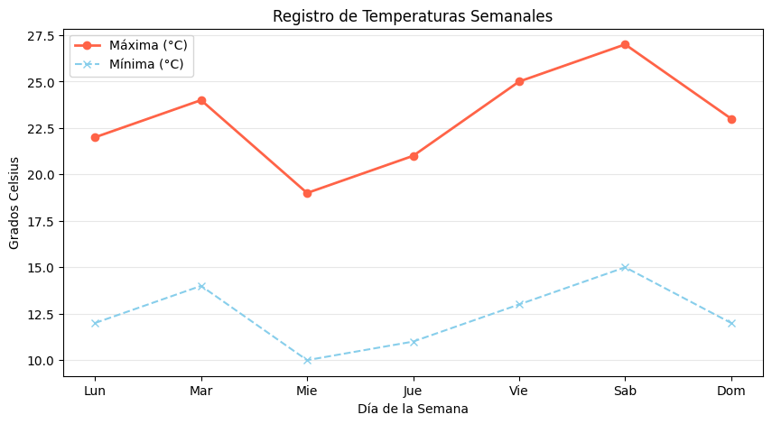

```python
dias = ['Lun', 'Mar', 'Mie', 'Jue', 'Vie', 'Sab', 'Dom']
temp_max = [22, 24, 19, 21, 25, 27, 23]
temp_min = [12, 14, 10, 11, 13, 15, 12]

plt.figure(figsize=(10, 5))
plt.plot(dias, temp_max, color='tomato', marker='o', label='Máxima (°C)', linewidth=2)
plt.plot(dias, temp_min, color='skyblue', marker='x', linestyle='--', label='Mínima (°C)')

plt.title('Registro de Temperaturas Semanales')
plt.xlabel('Día de la Semana')
plt.ylabel('Grados Celsius')
plt.legend()
plt.grid(axis='y', alpha=0.3)

plt.savefig('imgs/grafico_lineas.png', dpi=300, bbox_inches='tight')
plt.show()
```

# Gráfico de Barras (Lenguajes de Programación)

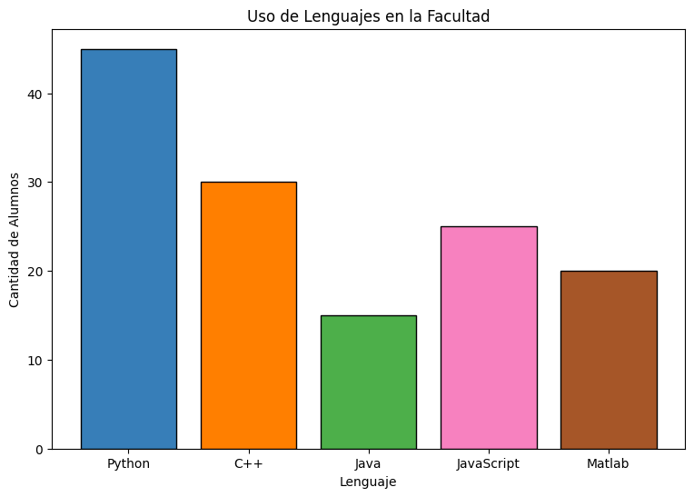

```python
lenguajes = ['Python', 'C++', 'Java', 'JavaScript', 'Matlab']
estudiantes = [45, 30, 15, 25, 20]

plt.figure(figsize=(9, 6))
colores = ['#377eb8', '#ff7f00', '#4daf4a', '#f781bf', '#a65628']

plt.bar(lenguajes, estudiantes, color=colores, edgecolor='black')

plt.title('Uso de Lenguajes en la Facultad')
plt.xlabel('Lenguaje')
plt.ylabel('Cantidad de Alumnos')

plt.savefig('imgs/grafico_barras.png', dpi=300, bbox_inches='tight')
plt.show()
```

### Explicacion:

La visualización compara la cantidad de estudiantes que prefieren distintos lenguajes de programación en la facultad. Se optó por un **grafico de barras** ya que facilita la comparación directa de magnitudes entre categorías discretas y permite identificar el elemento dominante de un vistazo.

# Histograma (Distribución de Calificaciones)

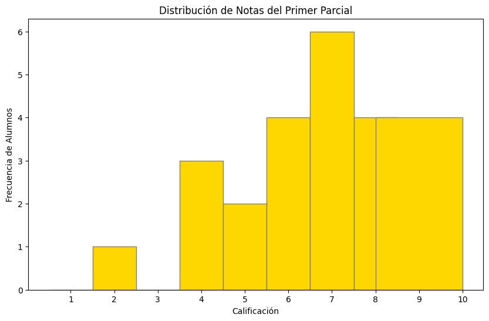

```python
# Lista de notas (datos crudos)
notas = [2, 4, 4, 5, 6, 6, 6, 7, 7, 7, 7, 8, 8, 8, 9, 9, 10, 5, 6, 7, 8, 4, 9, 7]

plt.figure(figsize=(10, 6))
# Definimos los rangos manualmente del 1 al 10
plt.hist(notas, bins=[1, 2, 3, 4, 5, 6, 7, 8, 9, 11], color='gold', edgecolor='gray', align='left')

plt.title('Distribución de Notas del Primer Parcial')
plt.xlabel('Calificación')
plt.ylabel('Frecuencia de Alumnos')
plt.xticks(range(1, 11))

plt.savefig('imgs/histograma.png', dpi=300, bbox_inches='tight')
plt.show()
```

### Explicacion:

Este gráfico representa cómo se distribuyen las calificaciones de un grupo de alumnos en un examen parcial. Se utilizó un **Histograma** para agrupar los datos en intervalos numéricos, permitiendo analizar la densidad de los resultados y la forma de la distribución del curso.

# Gráfico de Dispersión (Peso vs Altura)

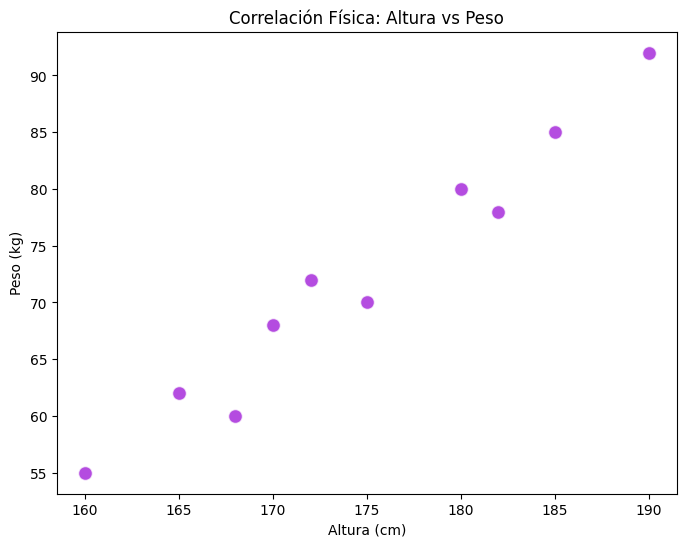

```python
altura = [160, 165, 170, 175, 180, 185, 190, 168, 172, 182]
peso = [55, 62, 68, 70, 80, 85, 92, 60, 72, 78]

plt.figure(figsize=(8, 6))
plt.scatter(altura, peso, color='darkviolet', s=100, alpha=0.7, edgecolors='white')

plt.title('Correlación Física: Altura vs Peso')
plt.xlabel('Altura (cm)')
plt.ylabel('Peso (kg)')

plt.savefig('imgs/grafico_dispersion.png', dpi=300, bbox_inches='tight')
plt.show()
```

### Explicacion:

El gráfico de dispersión explora la relación entre la estatura y el peso de una muestra de diez personas. Se eligió este **Grafico de Dispersion** para identificar posibles correlaciones o patrones visuales entre dos variables numéricas independientes.

# Gráfico de Torta (Uso de Energía)

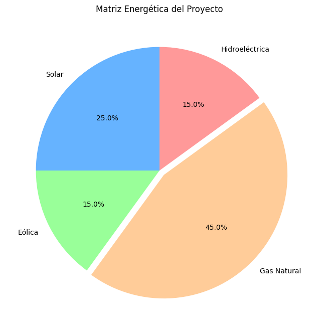

```python
fuentes = ['Solar', 'Eólica', 'Gas Natural', 'Hidroeléctrica']
porcentajes = [25, 15, 45, 15]

plt.figure(figsize=(8, 8))
plt.pie(porcentajes, labels=fuentes, autopct='%1.1f%%', startangle=90,
        colors=['#66b3ff','#99ff99','#ffcc99','#ff9999'], explode=(0, 0, 0.05, 0))

plt.title('Matriz Energética del Proyecto')
plt.savefig('imgs/grafico_torta.png', dpi=300, bbox_inches='tight')
plt.show()
```